[figure not shown]

# SMI606 Introduction to Quantitative Research: Module Outline

This module has been designed to help you develop your ability to conduct quantitative data analysis in the social sciences. The emphasis is not only on technical competence but also on understanding the principles behind the methods, as well as being able to competently interpret your results. We will be using real data with countless examples from across the social sciences (e.g., politics, economics, psychology, sociology, criminology, etc.) to learn about descriptive, exploratory, and inferential statistics. In doing so, we will cover topics such as data distributions, measurement, causality, correlation, regression, cluster analysis, spatial analysis, sampling and populations, and probability theory, using the R statistical programming language.

Dr Calum Webb https://www.sheffield.ac.uk/smi/people/academic/calum-webb (Sheffield Methods Institute)https://www.sheffield.ac.uk/smi  
2021-09-15

**Module**: SMI606

**Title**: Introduction to Quantitative Research

**Credit Value**: 15

**Level**: Postgraduate

**Semester**: Autumn 2021-22

**Module Leader**: Dr. Calum Webb (c.j.webb@sheffield.ac.uk)

**Time**: 9:00-10:50 Wednesdays (Week 1-5, 7-11)

**Location**: Hadfield Building Computer Room E61

**Consultation & Feedback Hours**: 15:00-16:00 Wednesdays (Week 1-12)

Book through Google Calendar by [clicking here](https://calendar.google.com/calendar/selfsched?sstoken=UUNxY3BJODNXMC00fGRlZmF1bHR8NmZlNjcyMzA2YjM4Y2NmNjMyZWNjN2ZjMThmMTk4YWE).

**Details**

*You may book up to two appointment slots back-to-back (20 minutes). Please do so well in advance. When you book an appointment, it will be added to your Google Calendar automatically: I would strongly recommend linking your Google Calendar to your phone, laptop, and/or tablet.*

*On booking an appointment the invite will contain a Google Meets link by default. If you would like to meet face to face, please edit the appointment description or title to reflect this.*

*Please cancel your appointment as soon as possible if you can no longer attend. This means that other students will be able to take advantage of any freed up time.*

**Weekly Drop-in Sessions**: 16:00-17:00 Thursdays (Week 1-5, 7-12) - Virtual only initially. No booking required. Meeting room: meet.google.com/qvo-cpkp-ndz

**Details**

*The purpose of this drop-in is for you to get support, either individually or as a group, with any of the content in the module that you may be struggling with, including writing code in R.*

*You can use this drop-in for troubleshooting any problems you are having with R (any errors), for asking questions about the module content or about the assessments. You do not need to make an appointment.*

*Please keep in mind that multiple students may be in the drop-in session at any one time. If it is very busy you may not be able to receive support, but we will try and answer all questions.*

*If you still have questions after the drop-in session you can ask these on the discussion board (Piazza) on Blackboard. If you feel like you are not able to ask your questions in front of other students at the drop-in session, please consider booking a one-to-one appointment during consultation and feedback hours.*

**This module will be taught in a computer room, but it is strongly recommended that you use your own laptop for exercises in `R` as you may not have access to university computers while working on your assessments.**

## Learning Outcomes: What will you learn?

*Make sure you revisit these learning outcomes occasionally and take stock of what outcomes you feel you are reaching, which ones you are struggling with, and which ones you might need more support with.*

By the end of the module, you should be able to demonstrate that you:

1. Understand the nature and assumptions that underpin quantitative research and analysis in social research
2. Can produce appropriate descriptive statistics for different variable types, as well as data visualisations, to understand data distributions
3. Can produce statistics to quantify, describe, and make inferences about relationships between variables, including generalisation to populations and claims of causality
4. Can create statistical models for assessing the relationship between continuous and binary categorical dependent variables and multiple independent variables
5. Can use other quantitative methods for exploring clustering and grouping among observations
6. Can use `R` to show patterns spatial patterns and concentration

## Teaching: How will I be taught and what do I need to do each week?

*I would recommend setting up recurring events in your Google calendar at the start of term so you know when and where each session is.*

[output not shown]

## Course outline: What will be covered each week?

*Rather than giving ‘homework’ style tasks after each session that some people might be used to, you will often be expected to complete some preparation before each session: whether this is reading an article, completing a task, or watching a pre-recorded video. This is why it’s important for you to always check in advance what preparation needs to be completed.*

Below are details on which topics will be covered in each week of the course, along with some suggested reading on the topic. As the content becomes more complicated, I have chosen complementary readings where the first reading will cover the more theoretical aspects of the analytical method and the second reading will reinforce this theory and apply it in practice using `R`.

For comprehensive details of the suggested reading for each week, you should **use the reading and resource list**. More details for each week and further information on how to find the recommended and additional reading will be included on each week’s Blackboard page (accessed through the sidebar).

[output not shown]

[figure not shown]

*Illustrations by [Allison Horst](https://github.com/allisonhorst/stats-illustrations)*

## Reading and Learning Resources

You can find a detailed guide to recommended reading and independent learning activities in the Reading and Resources List page, which can be used in conjunction with the library Resources List.

Conventionally, a course like this would have one set methods textbook. However, because `R` is a statistical programming language used across multiple disciplines with a very large number of additional libraries that are continually being developed, I would encourage you to experiment with different learning materials to find what works best for you. One author’s textbook chapter on data manipulation might, for example, not work as well for you as anothers. Further, you should feel free to use online resources if this helps you learn — because `R` is so widely used, you will find a lot of existing support.

With that said, there are three textbooks I would strongly recommend that you but or access from the library throughout the module:

- Rowntree, D. (1981). ‘Statistics without tears: An introduction for non-mathematicians’. ([Around £10](https://uk.bookshop.org/books/statistics-without-tears-an-introduction-for-non-mathematicians/9780141987491) also available for free on [Archive.org](https://archive.org/details/statisticswithou00rown_0))
- Fogarty, B. (2018). ‘Quantitative Social Science Data with R: An introduction’. ([Around £35](https://uk.bookshop.org/books/quantitative-social-science-data-with-r-an-introduction/9781526411501))
- Imai, K. (2018) ‘Quantitative Social Science: An introduction’. Princeton University Press. Online copies are freely accessible through the library’s StarPlus service or available from publisher [for around £40](https://press.princeton.edu/books/paperback/9780691175461/quantitative-social-science)

In the reading and resource list you will find the following:

- **Recommended methods textbooks**, where the content has been checked to ensure it aligns to the learning outcomes of this module.
- A list of **online resources and activities designed to help people learn `R`**.
- **Academic reading material** on statistical and social science theory.

## Responsibilities and Independent Learning

This is a 15-credit module; therefore, it is expected it will require 150 study hours per student (including the above teaching hours). As a rough guideline this means you should expect to devote around 10 hours of study time per week to this module during a typical 15-week semester.

Everyone will be starting this module with different kinds of experience: some people might have never studied any kind of social statistics before and many will have never had to write code. I am unlikely to set you 8-10 hours of directed independent learning each week; it is up to you to identify your learning needs and use the resources provided to meet them. I am happy to help you with this process and provide suggestions if you find yourself stuck for things to do each week.

To ensure your independent learning is productive, you should **regularly think about what parts of the module are challenging you**. Examples of this might be:

- Reading and manipulating data in `R`.
- Interpreting the output of statistical tests.
- Creating graphs.

You should then **use the reading and resources list to plan some independent learning activities for that week**.

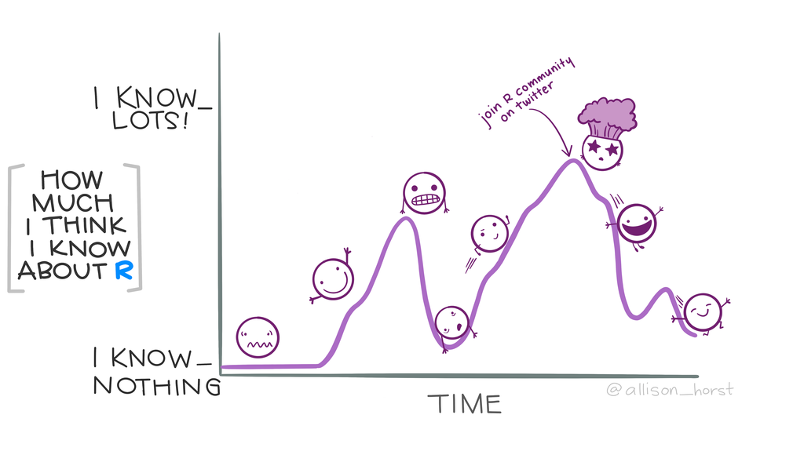

## Assessment

This module will be assessed through two written data analysis projects using R to ensure that you have achieved the aims and learning outcomes of this module.

The first 1,000-word limit submission counts for 40% of your final module grade and is due in December; the second 2,000-word limit submission counts for 60% of your grade and is due at the end of January. More details about these assessments will be made available as the module progresses. The assessments will be posted on Blackboard well in advance of the relevant deadlines.

### Word limits

Please note that word limits will be enforced as per the [student handbook](https://sites.google.com/sheffield.ac.uk/smipostgraduatestudenthandbook/marks-and-marking-criteria). This means that you should not exceed the word limit. You will not be penalised for writing under the word limit, but should bear in mind that if you write substantially less than the limit you are unlikely to have included enough detail to demonstrate you have achieved all of the requirements for the assignment. Bibliographies (if necessary) are not included in word counts, but in-text citations are. You may choose whatever referencing format you wish (e.g., APA, Chicago, etc.), but please just be consistent throughout your submission.

Tables and graphs are **not** included in the word limit, though they should be used appropriately (there must be a good reason if long sections of text are included in a table). There are no limits on the number of tables or graphs you can use, but the content of all graphs and tables should be discussed and pertinent parts should be *at least* briefly described in the main text.

`R` code, comments, and output is also **not** included in the word limit, however, all pertinent information should always be in the main body of your assigment.[^1] Comments should be restricted to explaining the purpose of the code, and not used for communicating or interpreting the results.

### Submission

Coursework must be submitted online through Blackboard/Turnitin and by no later than 12:00pm (noon) on the day of the deadline. Any unauthorised late submissions after midday on the day of the deadline will incur a penalty of up to 100%, as per the [student handbook](https://sites.google.com/sheffield.ac.uk/smipostgraduatestudenthandbook/late-submission). Marked coursework will generally be returned within 3 working weeks. The pass mark for this module is 50% overall. Any change to assessment arrangements will be announced in Blackboard.

### Reassessment

In the case of students who fail the assessment of this module, repeat assessment will be by a written, essay examination. Further instructions will be communicated to those who fail the module. Resit candidates must consult Blackboard for further information, up until the time of the reassessment, not merely in semester time. Resit marks will be capped at 50%.

### Use of Unfair Means in the Assessment Process

Because coursework, unlike examinations, is not invigilated, the University lays down general rules so that everyone is clear about what is acceptable practice. These rules are set out formally in the regulations for non-invigilated examinations in [Part I of the University Calendar](https://www.sheffield.ac.uk/calendar). Further information can be found here: [Unfair Means – Advice to Students](https://www.sheffield.ac.uk/polopoly_fs/1.40934!/file/student_guidance_on_unfair_means.pdf).

#### What constitutes unfair means?

The basic principle underlying the preparation of any piece of academic work is that the work submitted must be your own work. Plagiarism, submitting bought or commissioned work, double submission (or self-plagiarism), collusion and fabrication of results are not allowed because they violate this principle. Rules about these forms of cheating apply to all assessed and non-assessed work. More details can be found in the [student handbook](https://sites.google.com/sheffield.ac.uk/smipostgraduatestudenthandbook/unfair-means).

#### What happens if I use unfair means?

Any form of unfair means is treated as a serious academic offence and action may be taken under the Discipline Regulations. Where unfair means is found to have been used, the University may impose penalties ranging from awarding a grade of zero for the assignment through to expulsion from the University in extremely serious cases.

#### Detection of Unfair Means

The University subscribes to a national plagiarism detection service called Turnitin which helps academic staff identify the original source of material submitted by students. It is also a resource, which can help tutors to advise students on ways of improving their referencing techniques. Your work will be checked by this service and results will be assessed by the marker.

### Illness, Coursework Extensions and Extenuating Circumstances

SMI’s policy on coursework extensions and extenuating circumstances can be found in the SMI Postgraduate Handbook. If you wish to apply for a coursework extension, you should contact SMI in the first instance (smi@sheffield.ac.uk), in advance of the coursework deadline, and include the relevant Extenuating Circumstances Form plus medical certification if appropriate. Your application will then be considered, and the outcome communicated to you as soon as possible.

**Please note that module leaders cannot grant extensions**.

## Feedback

Feedback on the assessments will generally be provided within three working weeks of the submission date. However, you will also receive regular feedback on non-assessed activities to help you improve your ability, understanding, and work prior to assessment.

## Module Evaluation

We always welcome your comments and feedback as the module progresses, and informal evaluation of this kind will take place throughout the module. Students will also be invited to complete an anonymised module evaluation form towards the end of the module. These will be reviewed by SMI’s Director of Learning and Teaching and the Module leader. A summary will then be considered by SMI’s Staff-Student Committee and the SMI Learning & Teaching Committee. Any changes made to the module as an outcome of student evaluation will be communicated to new/future cohorts of students and in the following year’s module Blackboard pages.

[^1]: You can use the Rstudio [`wordcountaddin`](https://github.com/benmarwick/wordcountaddin) Add In to get an accurate word count of your assignment if it is written in Rmarkdown, which you are encouraged to use (requires installation with `devtools`: `devtools::install_github("https://github.com/benmarwick/wordcountaddin")`).